# Logistic Regression

***Loading in Packages***

```python
import pandas as pd
import numpy as np
from numpy.random import rand, seed
import matplotlib.pyplot as plt
import sklearn as skl
```

***Loading in Test and Training Data***

```python
oring_df = pd.read_csv('oring.csv', header =0)
```

***Data Exploration***

```python
oring_df.head(5)
```

|  | Temp | Failure |
| --- | --- | --- |
| 0 | 53 | 1 |
| 1 | 56 | 1 |
| 2 | 57 | 1 |
| 3 | 63 | 0 |
| 4 | 66 | 0 |

```python
oring_df.dtypes
```

```
Temp       int64
Failure    int64
dtype: object
```

```python
oring_df.shape
```

```
(24, 2)
```

***Problem 1***

**Part 1 - Value of X that minimizes function**

Functions are minimized when their derivative is equal to zero. Function and derivative are posted below:

function = x<sup>2</sup> + 6x

derivative = 2x + 6

Solve for 2x + 6 = 0

***x = -3***

The function is minimized when x = -3.

**Part 2 - Using gradient descent to find value of x which minimizes function**

```python
#initialize weight
Wo = 1

#establish number of runs
n_runs = 1000

#learning rate
alpha = 0.1

for i in range(n_runs):
    #take derivative of function for deltaF
    deriv = 2*Wo + 6

    #implement weight update
    new_Wo = Wo - alpha*deriv

    #reset wo value
    Wo = new_Wo

    #break statement if updated weights produce zero value derivative
    if deriv == 0:
        break

#print final Wo value
Wo
```

```
-2.999999999999999
```

As shown above, gradient descent algorithm produced same weight (x= -3) as setting derivative equal to zero.

***Problem 2***

**Part 1 - Normalizing Launch Temperature**

```python
#add normalized temperature column
oring_df['Norm_Temp'] = (oring_df.Temp - oring_df.Temp.mean())/oring_df.Temp.std()
oring_df.head(10)
```

|  | Temp | Failure | Norm_Temp |
| --- | --- | --- | --- |
| 0 | 53 | 1 | -2.293007 |
| 1 | 56 | 1 | -1.886366 |
| 2 | 57 | 1 | -1.750818 |
| 3 | 63 | 0 | -0.937535 |
| 4 | 66 | 0 | -0.530893 |
| 5 | 67 | 0 | -0.395346 |
| 6 | 67 | 0 | -0.395346 |
| 7 | 67 | 0 | -0.395346 |
| 8 | 68 | 0 | -0.259799 |
| 9 | 69 | 0 | -0.124252 |

**Part 2 - Building an O-Ring Failure Probability Model using Logistic Regression with Gradient Descent**

```python
#establish sigmoid function
def sigmoid_function(x):
    sig = 1/(1 + np.exp(-x))
    return sig

#set up x and y
x_mod = pd.DataFrame(oring_df.Norm_Temp)
y_mod = pd.DataFrame(oring_df.Failure)

#set up columns of ones for Wo
x_mod['Ones'] = pd.Series(np.ones(len(x_mod))).T

#establish number of runs
n_runs = 1000

#learning rate
alpha = 0.1

#initialize weights
w0 = 5
w1 = 15

for i in range(n_runs):
    #create matrix of weights
    w = pd.DataFrame([w1,w0])

    #calculate wx
    wx = np.dot(x_mod,w)

    #calculate weights using graident descent
    new_w1 = w1 - alpha*np.sum(np.dot((sigmoid_function(wx)-y_mod).T,x_mod.iloc[:,0]))
    new_w0 = w0 - alpha*np.sum(np.dot((sigmoid_function(wx)-y_mod).T,x_mod.iloc[:,1]))

    if(w0 - new_w0 == 0) and (w1 - new_w1 == 0):
        break
    else:
        #reset weights
        w0 = new_w0
        w1 = new_w1

#print out final weights
print('w0',w0)
print('w1',w1)
```

```
w0 -1.1028092149015363
w1 -1.263917346380835
```

Based on our above model, you can predict O-ring failure as a result of Normalized Launch Temperature (x) using the following formula:

O-Ring Failure (Y=1) if:

$\large\ \frac{1}{1 + e^{{(1.103 + 1.264x)}}} > 0.5 $

Using weights above and creating an O-Ring Failure function:

```python
def o_ring_failure(x):
    norm_temp = (x - oring_df.Temp.mean())/oring_df.Temp.std()
    failure_probability = 1 / (1 + np.exp(1.103 + (1.264*norm_temp)))
    return failure_probability
```

**Part 3 - Plotting O-Ring Failure Data vs. Logistic Function Predictions**

```python
#create full probability series using output from o_ring_failure function
x = list(np.linspace(40,80,4000))
output = pd.Series(list(map(o_ring_failure, x)))
final = pd.concat([pd.Series(x),output],axis=1)
final.columns = ['Temperature','Probability']
final.head(5)
```

|  | Temperature | Probability |
| --- | --- | --- |
| 0 | 40.000000 | 0.982410 |
| 1 | 40.010003 | 0.982380 |
| 2 | 40.020005 | 0.982351 |
| 3 | 40.030008 | 0.982321 |
| 4 | 40.040010 | 0.982291 |

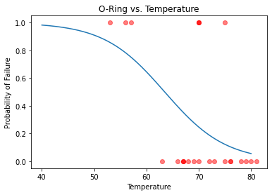

```python
fig, ax = plt.subplots()
ax.scatter(oring_df.Temp, oring_df.Failure, c="red", alpha=0.5,
           label="O-Ring and Temperature")
ax.set_xlabel("Temperature")
ax.set_ylabel("Probability of Failure")
ax.set_title("O-Ring vs. Temperature")
plt.plot(final.Temperature,final.Probability)
plt.show()
```

For plot above, red points represent original o-ring failure data and blue line is failure probability prediction using logistic regression model.

**Part 4 - Probability of O-Ring Failure with 31 Degree Temperature**

```python
o_ring_failure(31)
```

```
0.996183732436443
```

Based on this model, there was a 99.6% chance of o-ring failure with a 31 degree launch temperature. It would have been difficult to provide a convincing argument against the launch due to the lack of data available at such low temperatures (only had data for 3 shuttle launches below 60 degrees).